# Effect of Walking Fitness on Brain Health

Edward Huffstetler

2026-03-17

Github repository contains summary PDF (results only/no code), and instructions for how to run pipeline with real data: https://github.com/Edward932/Brain-Age-Gap-Demo-Project

This markdown file is the reproducible demo pipeline for the Brain Age Gap (BAG) analysis summarized in Bag_Summary.PDF. It trains an Elastic Net and XGBoost model to predict age from ~1,400 MRI-derived summary measures. It then computes BAG (predicted age - true age) and tests whether two-minute walk distance is associated with BAG.

Because the raw AABC data are governed by a data-use agreement, this Rmd runs by default using synthetic data that mimics the structure of the real dataset. To use the real data follow the instructions in the README. If you use synthetic data (the default option) the charts and graphs will not match BAG_Summary.PDF.

# Setup

This notebook assumes packages are installed. If you cloned the repo, the recommended way to install the same package versions is:

install.packages(“renv”); renv::restore(prompt = FALSE)

# Data Loading

Synthetic data is generated by default. To use real data follow the instructions in the README (requires downloading data).

```r
# To save time some models are pre-trained and loaded in
# If you change the seed, the pre-trained models may not reflect the new synthetic data
set.seed(1)

# Importing functions
source("DataProcessing.R")

# By default pipeline uses synthetic data (real data requires DUA access)
# Instructions to use real data are in the README
# Changing to FALSE will only work if instructions in README are followed
USE_SYNTHETIC_DATA = TRUE
if (USE_SYNTHETIC_DATA) {
  df_list = generate_synthetic_data()
} else {
  df_list = clean_real_data()
}

# MRI_df contains MRI summary measurements and age
MRI_df = df_list$MRI
```

# Model 1: Elastic Net

First, we fit an Elastic Net model to predict chronological age from MRI summary measurements. Predictions are generated out-of-fold via cross-validation to avoid leakage. These out-of-fold predictions are then used to compute BAG.

Because brain-age models often show age-dependent bias, we also apply a simple linear calibration of predicted age on true age using out-of-fold predictions, and then compute calibrated BAG. This calibration is intended to remove age dependence in BAG and may not improve RMSE.

For downstream analysis BAG is calculated for each patient, so data is not split into training and testing. Instead out-of-fold predictions are calculated for each patient.

```r
# Separating data into age (y_ridge) and MRI measurements (x_ridge) for training a elastic net model to predict age based on MRI data
y_ridge = MRI_df$age
x_ridge = as.matrix(MRI_df[ , !(names(MRI_df) %in% c("ID", "age"))])

# Training a elastic net model using 10 fold cross validation
# Out-of-fold age predictions are saved to calculate BAG
# Alpha of 0.014 was selected via brute force method
elastic_net_model = cv.glmnet(x_ridge, y_ridge, alpha = 0.014, nfolds = 10, standardize = TRUE, keep = TRUE)

# Extracting out-of-fold predictions for the optimal lambda value determined through CV
best_fit_index = elastic_net_model$index["min", "Lambda"]
pred_oof_EN = as.numeric(elastic_net_model$fit.preval[, best_fit_index])

# calculating BAG for each patient and root mean squared error of age prediction (no calibration)
bag_EN = pred_oof_EN - y_ridge
RMSE_EN = sqrt(mean((pred_oof_EN - y_ridge)^2))

# Using linear calibration to correct age-dependent bias in predictions
# Then rescaling predictions so the fitted line is y = x
cal_EN = lm(pred_oof_EN ~ y_ridge)
intercept_EN = coef(cal_EN)[1]
slope_EN = coef(cal_EN)[2]
pred_oof_corr_EN = (pred_oof_EN - intercept_EN) / slope_EN

# calibrated predicted age and calibrated BAG
bag_corr_EN = pred_oof_corr_EN - y_ridge
RMSE_corr_EN = sqrt(mean((pred_oof_corr_EN - y_ridge)^2))
```

# Elastic Net prediction plots before and after calibration

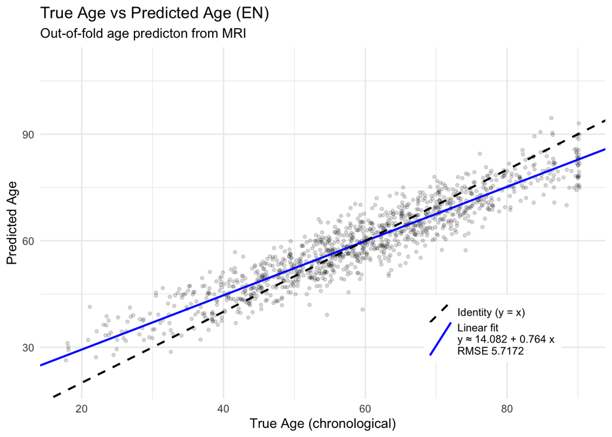

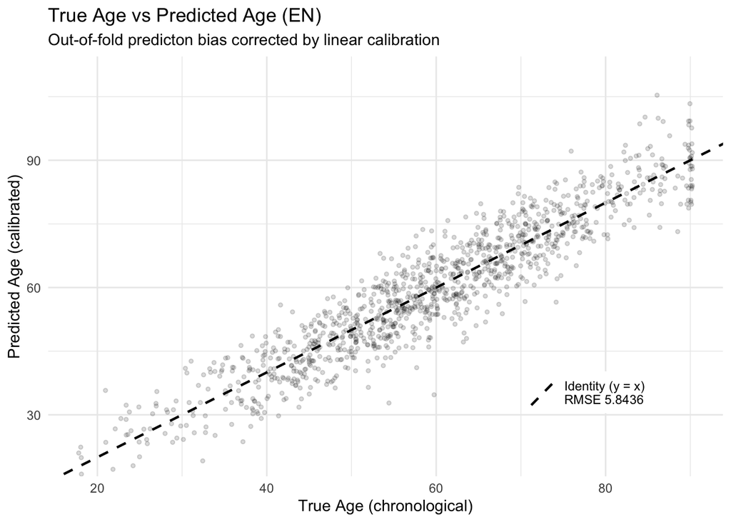

# Model 2: XGBoost

Next, we train an XGBoost model using cross-validated out-of-fold predictions. Hyperparameters were selected using a model-based optimization procedure (mlr3mbo) over a predefined search space, minimizing cross-validated RMSE. Hyperparameter optimization code is in the appendix at the bottom of this Rmd.

To keep knitting time manageable, the notebook can load cached cross-validation results in FAST_MODE. If FAST_MODE = FALSE, the full CV is recomputed (this may take a few minutes).

```r
# Separating data into age (y_xgb) and MRI measurements (x_xgb) for training a xgboost model to predict age based on MRI data
y_xgb = MRI_df$age
x_xgb = as.matrix(MRI_df[ , !(names(MRI_df) %in% c("ID", "age"))])

# Converting into XGBoost’s optimized DMatrix format
xgb_matrix = xgb.DMatrix(data = x_xgb, label = y_xgb)

# Creating a list of optimized hyperparameters
# hyperparameters where chosen by Bayesian-optimization-like procedure via the mlr3mbo package
# Code for hyperparameter optimization is located at the end of this file
params = list(objective = "reg:squarederror",
              eval_metric = "rmse",
              tree_method = "hist",
              max_depth = 4,
              min_child_weight = 81.07821,
              subsample = 0.7210051,
              colsample_bytree = 0.1494652,
              colsample_bynode = 0.2376824,
              eta = 0.02154221,
              gamma = 4.175431,
              alpha = 3.37655,
              lambda = 1.418648)

# Training XGBoost using 10 fold cross validation
# Out-of-fold age predictions are saved to calculate BAG
# This can take a few minutes to run so previous results are being loaded
# Change value to FALSE to run CV (may take a few minutes)
FAST_MODE = TRUE
if (FAST_MODE && USE_SYNTHETIC_DATA) {
  xgb_model = readRDS("xgb_cv.rds")
} else {
  xgb_model = xgb.cv(
    params = params,
    data = xgb_matrix,
    nrounds = 20000,
    nfold = 10,
    early_stopping_rounds = 80,
    verbose = 0,
    prediction = TRUE)
}

# Extracting out-of-fold predictions
pred_oof_xgb = xgb_model$cv_predict[[1]]
pred_oof_xgb = as.numeric(pred_oof_xgb)

# calculating BAG for each patient and root mean squared error of age prediction (no calibration)
bag_xgb = pred_oof_xgb - y_xgb
RMSE_xgb = sqrt(mean((pred_oof_xgb - y_xgb)^2))

# Using linear calibration to correct age-dependent bias in predictions
# Then rescaling predictions so the fitted line is y = x
cal_XGB = lm(pred_oof_xgb ~ y_xgb)
intercept_XGB = coef(cal_XGB)[1]
slope_XGB = coef(cal_XGB)[2]
pred_oof_corr_xgb = (pred_oof_xgb - intercept_XGB) / slope_XGB

# calibrated predicted age and calibrated BAG
bag_corr_xgb = pred_oof_corr_xgb - y_xgb
RMSE_corr_xgb = sqrt(mean((pred_oof_corr_xgb - y_xgb)^2))
```